# 180928_project

JunHyeongKim

2018년 9월 28일

## 데이터선정

1. 데이터 출처
- 진료내역 정보 [공공데이터 포털>진료내역 정보](https://www.data.go.kr/dataset/15007115/fileData.do)
- 건강검진 정보 [공공데이터 포털>건강검진 정보](https://www.data.go.kr/dataset/15007122/fileData.do)
2. 데이터 관련 사진

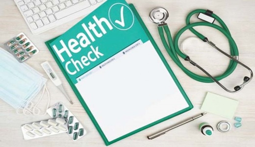

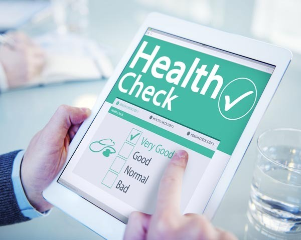

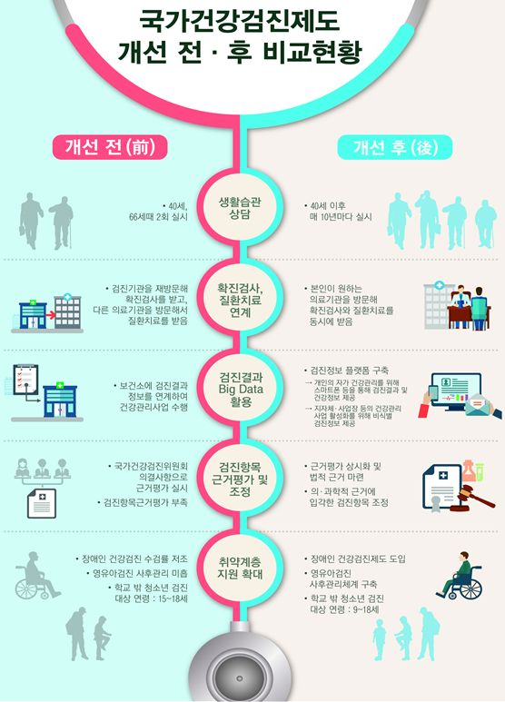

3. 데이터 선정 이유
- 로우데이터로 이루어져 있음
- 2000년대 초반부터 비교적 최근인 2016년 자료까지 있음
- 한 년도당 100만명의 표본을 포함하고 있음
- 응답의 코드화가 되어있어 데이터 편집이 용이함
4. 데이터의 일부

| 진료내역일련번호 | 성별코드 | 연령대코드 | 시도코드 | 요양개시일 | 서식코드 | 진료과목코드 | 주상병코드 | 부상병코드 |
| --- | --- | --- | --- | --- | --- | --- | --- | --- |
| 1 | 1 | 2 | 27 | 20121204 | 3 | 23 | J304 | J209 |
| 2 | 2 | 14 | 27 | 20121203 | 3 | 23 | I109 | I739 |
| 3 | 2 | 14 | 27 | 20121217 | 3 | 23 | K210 | R101 |
| 4 | 2 | 14 | 27 | 20121229 | 3 | 23 | K210 | R101 |
| 5 | 2 | 13 | 27 | 20121222 | 3 | 23 | E039 | M544 |

5. 데이터 분석의 방향
- 연도별 데이터를 성별, 나이대, 진료과목별로 구분한다.
- 각각 정리된 데이터를 비교나열하여 연도별 변화를 확인한다.
- 연도별 달라지는 높은 발병률의 질병, 증상 등을 확인한다.
- 이를 통해서 시간순으로 국민들의 신체적 변화 및 위험에 노출될 수 있는 질병 및 증상을 예측분석할 수 있다.

시간이 지나면서 국민들의 신체적인 변화 및 변화하는 질병들 분석. 이에따른 신체적 변화와 그에 따라 나타날 수 있는 질병을 비교분석하고, 현재 우리나라 건강검진 항목에 대한 결점 및 문제점 분석, 보완.